# Women’s Career Lifespans in U.S. Entertainment

Screen opportunity and Billboard Hot 100 visibility by age

Author

Brian Balzar

Published

August 17, 2026

## How to read the key measures

### “Women-coded” and “men-coded”

These are IMDb metadata classifications, not self-identified gender. For each performer, the analysis counts principal credits that IMDb labels `actress` or `actor`. A performer is **women-coded** when at least 90% of those classified credits are labeled `actress`, and **men-coded** when at least 90% are labeled `actor`. Performers between those thresholds are classified as ambiguous and excluded from binary comparisons.

### “Women-coded opportunity share”

An opportunity unit is one principal cast credit in a film, or participation in one television series during one calendar year. At each age, women-coded opportunity share is:

> Opportunities credited to women-coded performers ÷ opportunities credited to women-coded plus men-coded performers.

It is not the percentage of women who worked, the share of every speaking role, screen time, or an individual performer’s probability of being hired.

### “Five-year career interruption”

This is the last credited year before at least five consecutive calendar years without another qualifying principal opportunity. It is a **confirmed interruption**, not necessarily permanent retirement: a performer can later return. A reduction in the number or prominence of roles does not count, and recent final credits are censored until five follow-up years are observable. The interruption hazard is the conditional probability that a credited year at a given age is the beginning of such an interruption among established careers that have not already experienced one.

## Executive finding

The observation is substantially correct, but the age pattern is more revealing than a single “cliff after 35.”

Across U.S.-market IMDb titles, women-coded performers supply approximately half of principal opportunity units around age 30. Their share then falls sharply through the 30s and reaches roughly one quarter to one third by age 50. The decline is steeper in film than television.

In film, women-coded opportunity falls from 47.8% at age 30 to 39.5% at 35, 32.2% at 40, 28.5% at 45, and 25.5% at 50. Television follows the same direction, but retains a somewhat larger women-coded share in midlife.

For established performers entering during 2000–2010, the adjusted probability of reaching the final year before a five-year career interruption is 7.87% for women-coded performers at age 30 and 6.15% for comparable men-coded performers. That is an interruption-hazard ratio of 1.28 (95% CI 1.22–1.34).

The evidence therefore indicates two related patterns:

1. **A representation contraction:** many fewer opportunities are occupied by women as performer age rises.
2. **An early-career continuity penalty:** established women-coded performers are more likely to enter a long interruption during their late 20s and 30s. Among performers who have survived into the recently active pool, annual and five-year re-employment probabilities are much more similar. The disparity is therefore not well described as every working actress suddenly becoming unemployable at 35. It is better described as **progressive attrition followed by a narrower population of survivors**.

The Billboard Hot 100 extension shows a parallel age contraction among identifiable solo artists. Across 1995–2025, women’s median chart-active age is 28, compared with 31 for men. Only 22.0% of women’s artist-years occur at age 35 or older, versus 32.4% for men.

## The age-opportunity curve

An opportunity unit is one principal cast credit for a film, or participation in one television series during one calendar year. This prevents a performer in twenty episodes of one series from outweighing twenty separate film performers.

Share of classified principal opportunities credited to women-coded performers

| Age | Film | All screen | Television |
| --- | --- | --- | --- |
| 30 | 47.8% | 48.0% | 48.2% |
| 35 | 39.5% | 40.9% | 41.8% |
| 40 | 32.2% | 34.4% | 35.9% |
| 45 | 28.5% | 31.5% | 33.6% |
| 50 | 25.5% | 28.3% | 30.3% |
| 60 | 23.0% | 26.1% | 28.7% |
| 70 | 24.5% | 29.2% | 33.6% |

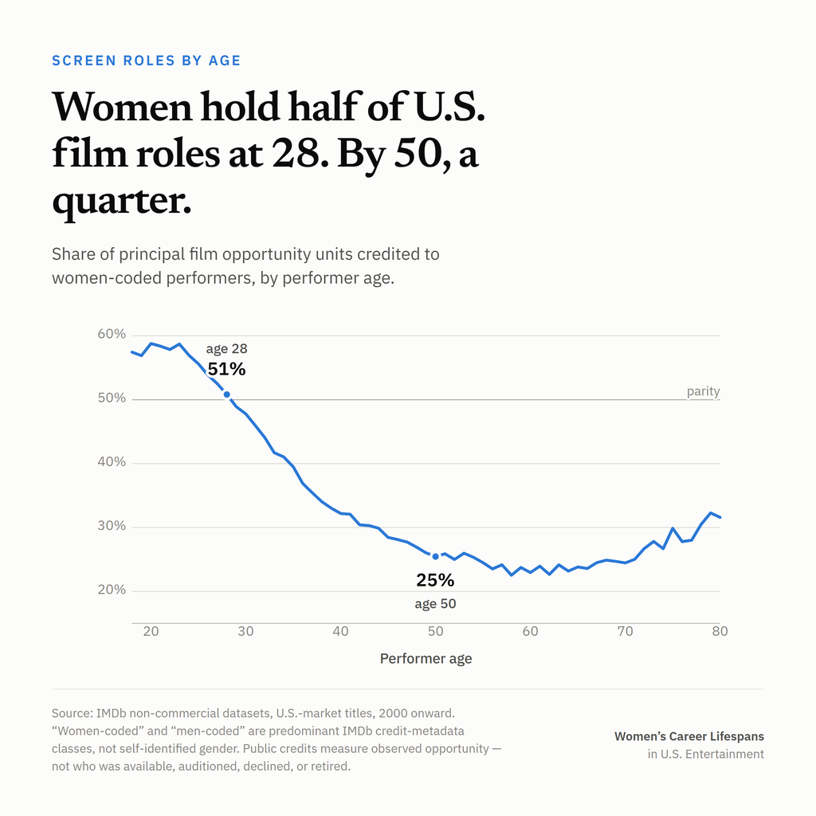

The pattern is continuous rather than a sudden disappearance at a single age. Women’s share is already declining during the late 20s and falls most rapidly from approximately 25 through the early 40s.

### Is 35 the cliff?

The data do not identify a unique onset at 35. Representation declines through the late 20s and 30s; by 35, women-coded film share has already fallen below 40%. The decline then slows in the early 40s, leaving representation at a lower plateau rather than producing a later recovery.

## Career continuity and five-year interruption

The career analysis follows performers whose first observed principal credit occurred from 2000–2010 at ages 18–35 and who accumulated credits in at least two of their first five years. A career interruption occurs at the last credited year before five consecutive years without another principal credit. Death and the end of available data are censored.

The model covers 20,561 established performers and adjusts for entry age, entry year, and early-career role volume. Uncertainty is clustered by performer.

Adjusted hazard of the first five-year career interruption

| Age | Women-coded interruption hazard | Men-coded interruption hazard | Interruption hazard ratio | 95% CI |
| --- | --- | --- | --- | --- |
| 25 | 6.55% | 5.86% | 1.12 | 1.05–1.19 |
| 30 | 7.87% | 6.15% | 1.28 | 1.22–1.34 |
| 35 | 6.96% | 5.89% | 1.18 | 1.12–1.25 |
| 40 | 4.38% | 4.29% | 1.02 | 0.94–1.11 |
| 45 | 2.15% | 2.24% | 0.96 | 0.83–1.11 |

The women-to-men interruption difference is largest around age 30, remains elevated at 35, and is no longer distinguishable by age 40 among this entry cohort. This finding survives alternative interruption definitions:

- Three-year gap at age 30: ratio 1.15
- Five-year gap at age 30: ratio 1.28
- Seven-year gap at age 30: ratio 1.33

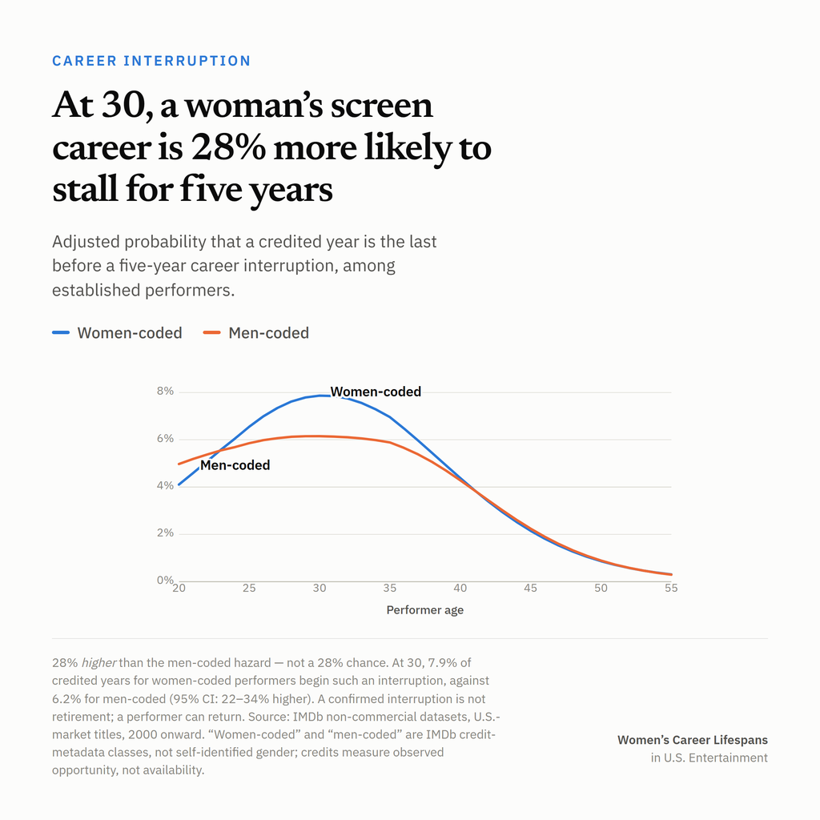

This is compatible with a selection process: women experience more interruptions during the age range when careers are being consolidated. Those who remain in the industry later are a more selected group, making conditional continuation rates look more equal than the representation totals.

## Film and television are not interchangeable

Film shows the largest contraction. At age 50, women-coded performers receive 25.5% of film opportunity units, compared with 30.3% in television. At age 60, the corresponding figures are 23.0% and 28.7%.

Five-year forward continuity among already credited performers is also much closer to parity in television. Television appears to function as a partial career-preservation channel, although it does not eliminate the shrinking share of women with age.

## Has the situation improved?

Yes, but the shape of the disparity remains.

Women-coded opportunity share by release period

| Age | 2000-2012 | 2013-2025 |
| --- | --- | --- |
| 30 | 44.5% | 50.9% |
| 35 | 36.8% | 43.9% |
| 40 | 30.7% | 37.2% |
| 45 | 27.9% | 33.7% |
| 50 | 24.8% | 30.5% |

The later period is approximately six percentage points more inclusive at each of these milestone ages. Nevertheless, women-coded opportunity still drops from near parity at age 30 to about 31% at age 50 in 2013–2025.

## A parallel case: Billboard Hot 100 solo artists

The music extension examines identifiable solo performers on weekly Billboard Hot 100 charts from 1995–2025. Each artist counts once per chart-active year, regardless of the number of songs. The analysis includes 1,333 classified solo artists and 4,208 artist-years. Bands, collaborations, and names that could not be matched reliably are excluded; the resulting solo sample represents 49.8% of all chart rows.

### Charting women are consistently younger

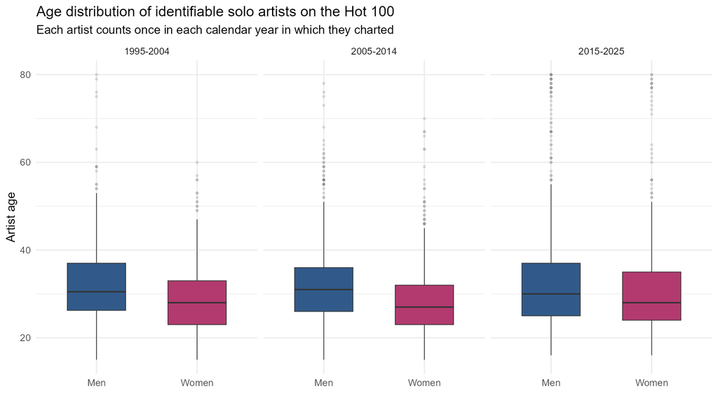

Across 1995–2025, the median unique artist-year age is 28 for women and 31 for men. Women are age 35 or older in 22.0% of their chart-active years, compared with 32.4% for men.

The artist-week sensitivity is more unequal: only 16.5% of women’s visible chart weeks occur at age 35 or older, versus 31.9% for men. This indicates that the difference is not limited to how many older artists appear; older men also sustain substantially more weekly chart presence.

### Five-year chart return diverges after 40

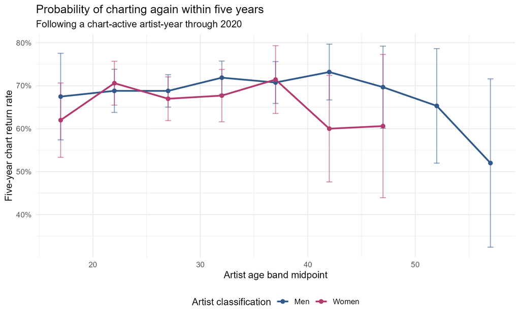

Return rates are broadly similar through the 30s. At ages 40–44, however, 60.0% of women’s chart-active years are followed by another chart year within five years, compared with 73.2% for men. At ages 45–49 the rates are 60.6% and 69.7%, respectively. These are descriptive return probabilities, not proof that the industry caused the difference.

The chart archive comes from the continuously updated [mhollingshead Billboard Hot 100 repository](https://github.com/mhollingshead/billboard-hot-100). Artist identity, birth date, gender, and the required MusicBrainz artist identifier are queried through the [Wikidata Query Service](https://query.wikidata.org/). MusicBrainz is used as an identity-control field, not as the source of the demographic values. Billboard’s underlying chart methodology changes over time, so period comparisons describe the chart as it existed in each era rather than a mechanically identical market measure.

## Robustness

The central representation curve changes very little when:

- predominant credit-class thresholds are changed from 90% to 80% or 95%;
- roles are restricted to the top three or top five principal cast positions;
- career interruption is defined as three, five, or seven years.

All 11 automated real-data validation checks passed, in addition to seven unit tests for the panel and metric functions.

## What this study measures—and what it cannot

### It measures

- observed principal screen-credit opportunity by performer age;
- film-title and television-series-year participation;
- continued participation among recently active performers;
- long career interruptions among an established entry cohort;
- age distributions and five-year return among identifiable Billboard Hot 100 solo artists.

### It does not measure

- auditions, offers, or roles declined;
- whether someone was actively seeking work;
- salary, earnings, or employment days;
- exact screen time or dialogue;
- production nationality—U.S.-region title metadata indicate U.S. market availability, not necessarily American ownership or filming;
- self-identified gender. “Women-coded” and “men-coded” refer to the predominant `actress` or `actor` category in IMDb’s credit metadata;
- discriminatory intent or a uniquely causal effect of age;
- the ages or gender composition of excluded bands, groups, and unresolved collaborative Billboard credits.

The results establish an age-associated opportunity and continuity gap. They do not, by themselves, determine how much is caused by casting discrimination, labor supply, career preferences, caregiving, health, representation, or other mechanisms.

## Data and methods

### Sources and attribution

- **Screen credits and performer metadata:** [IMDb Non-Commercial Datasets](https://developer.imdb.com/non-commercial-datasets/), specifically `name.basics`, `title.basics`, `title.principals`, `title.akas`, `title.episode`, and `title.ratings`. The analysis snapshot was downloaded August 17, 2026. IMDb supplies the upstream records; all classifications, filters, age calculations, models, and conclusions in this report are the author’s.
- **Weekly chart history:** the [`mhollingshead/billboard-hot-100`](https://github.com/mhollingshead/billboard-hot-100) archive, which republishes historical records for the [Billboard Hot 100](https://www.billboard.com/charts/hot-100/). The archive snapshot was downloaded August 17, 2026; this study analyzes 1995–2025.
- **Solo-artist identity metadata:** the [Wikidata Query Service](https://query.wikidata.org/) supplied human-entity status, birth date, gender label, and the [MusicBrainz artist identifier](https://musicbrainz.org/doc/MusicBrainz_Identifier) used as an additional identity requirement. MusicBrainz was not queried for birth date or gender.
- **Contextual comparison studies:** the USC Annenberg Inclusion Initiative and Geena Davis Institute reports linked below are interpretive comparisons only; their observations are not pooled into this project’s estimates.

No upstream IMDb or Billboard source rows are redistributed. The repository contains code, manifests, and aggregate derived results. See the complete [source-data and licensing notes](https://github.com/brianbalzar/hollywood-women-careers/blob/main/LICENSE-CONTENT.md).

The source files were downloaded from the [IMDb Non-Commercial Datasets](https://developer.imdb.com/non-commercial-datasets/) on August 17, 2026. The build contains 7,927,471 usable principal credits belonging to 156,950 performers with birth-year data and 1,547,880 film or television episode titles from 1995–2025.

Titles were included when IMDb contained a U.S.-region alternative title for the title or its parent television series. Documentary, news, reality television, talk show, game show, and adult genres were excluded. Primary analyses use ages 20–70 or the range supported by each cohort design.

Related manual content research provides a useful external check. USC’s study of 1,600 popular films found women represented only 23.9% of speaking characters aged 40 and older ([USC Annenberg Inclusion Initiative](https://annenberg.usc.edu/sites/default/files/2023/08/17/1600pop_3.pdf)). The Geena Davis Institute has separately documented severe underrepresentation of women among characters over 50 ([Women Over 50](https://geenadavisinstitute.org/research/women-over-50-the-right-to-be-seen-on-screen/)) and gender differences in occupation, parenthood, and aging narratives among characters over 40 ([Missing in Action](https://geenadavisinstitute.org/research/menopause-in-film-study-2025/)).

## Bottom line

The strongest defensible conclusion is:

> Women’s screen careers are compressed through progressive attrition beginning before 35, with the steepest loss of representation extending through the early 40s. Film exhibits a larger contraction than television. Women who remain active later have continuation rates closer to men’s, but they represent a much smaller survivor population.

The parallel Billboard analysis points in the same general direction: women’s solo-artist chart participation is younger, contains substantially fewer artist-years and artist-weeks after age 35, and shows a lower five-year return rate after 40. Because group and collaboration credits are excluded, this music result should be read as evidence about identifiable solo performers rather than the entire recording market.

The next research phase should manually code a stratified sample of roles. That would determine whether the quantitative disappearance shown here is accompanied by a loss of occupational authority, romantic agency, narrative centrality, and non-familial identity.